# Maize Microarray Unsupervised Analysis

Adhithi Raghavan

# Introduction

This document explores gene expression signatures of nitrogen-use efficiency in maize.  
We analyze data from GSE32361, validate sample metadata, perform clustering, filter for reliable genes,  
apply ANOVA to rank treatment-sensitive genes, visualize patterns via heatmaps, assess cluster quality, and conduct PCA.

# 1. Data Loading and Inspection

**Objective:** Download and inspect the structure of the microarray data.

```r
#BiocManager::install("GEOquery") #already loaded it
library("GEOquery") #Otherwise wont work
gse<-getGEO("GSE32361")

# Extract expression and metadata
expression.data <- as.data.frame(exprs(gse[[1]])) #This exprs function will give me the expression from the gse I created. The gse is a list with 1 element - so need to tell it to find find from the first element of the list.
expression.metadata <- pData(gse[[1]])

# Inspect data structure
str(expression.data)
```

```
## 'data.frame':    84246 obs. of  90 variables:
##  $ GSM801254: num  11.58 12.2 6.28 5.51 8.22 ...
##  $ GSM801255: num  11.71 12.34 6.15 5.56 8 ...
##  $ GSM801256: num  11.55 12.2 6.25 5.53 8.23 ...
##  $ GSM801257: num  11.2 11.95 6.31 5.35 8.39 ...
##  $ GSM801258: num  11.73 12.36 6.45 5.25 8.36 ...
##  $ GSM801259: num  11.68 12.32 6.1 5.35 7.79 ...
##  $ GSM801260: num  12.55 13.01 6.34 5.46 7.81 ...
##  $ GSM801261: num  11.93 12.53 5.42 5.67 6.79 ...
##  $ GSM801262: num  12.08 12.72 6.43 5.34 7.91 ...
##  $ GSM801263: num  12.51 12.95 5.85 5.32 7.87 ...
##  $ GSM801264: num  12.5 12.91 6.08 5.2 7.79 ...
##  $ GSM801265: num  12.39 12.87 6.07 5.37 7.75 ...
##  $ GSM801266: num  12.72 13.2 6.05 5.33 7.44 ...
##  $ GSM801267: num  12.95 13.3 5.8 5.52 7.6 ...
```

[output cut: 76 more lines]

# 2. Metadata Preparation and perform checks

**Objective:** Extract key metadata columns for downstream analyses.

```r
#need to extract genotypes, growth nutrient, sampling time
#What they are called in metadata - geo_accession, genotype:ch1,  growth nutrient:ch1, sampletime:ch1

#Creating a data frame - with 4 columns

library(dplyr)
imp.metadata.columns <- expression.metadata %>% dplyr::select("geo_accession", "genotype:ch1", "growth nutrient:ch1", "sampletime:ch1") %>% as.data.frame()
```

```r
#For expression data - each column has the geo accession - so need to find the number of columns
# Number of samples
ncol(expression.data) # should be 90
```

```
## [1] 90
```

```r
nrow(expression.metadata) # should be 90
```

```
## [1] 90
```

```r
ncol(expression.data) == nrow(expression.metadata)
```

```
## [1] TRUE
```

```r
# Check sample ID correspondence
colnames(expression.data) == rownames(expression.metadata)
```

```
##  [1] TRUE TRUE TRUE TRUE TRUE TRUE TRUE TRUE TRUE TRUE TRUE TRUE TRUE TRUE TRUE TRUE TRUE TRUE TRUE TRUE TRUE TRUE TRUE TRUE TRUE TRUE TRUE TRUE TRUE TRUE TRUE
## [32] TRUE TRUE TRUE TRUE TRUE TRUE TRUE TRUE TRUE TRUE TRUE TRUE TRUE TRUE TRUE TRUE TRUE TRUE TRUE TRUE TRUE TRUE TRUE TRUE TRUE TRUE TRUE TRUE TRUE TRUE TRUE
## [63] TRUE TRUE TRUE TRUE TRUE TRUE TRUE TRUE TRUE TRUE TRUE TRUE TRUE TRUE TRUE TRUE TRUE TRUE TRUE TRUE TRUE TRUE TRUE TRUE TRUE TRUE TRUE TRUE
```

```r
# Check uniqueness
unique.ids <- unique(colnames(expression.data))
length(unique.ids)
```

```
## [1] 90
```

# 3. Unsupervised Clustering of Samples

**Objective:** Compute Euclidean distances, generate dendrograms, and color by factors.

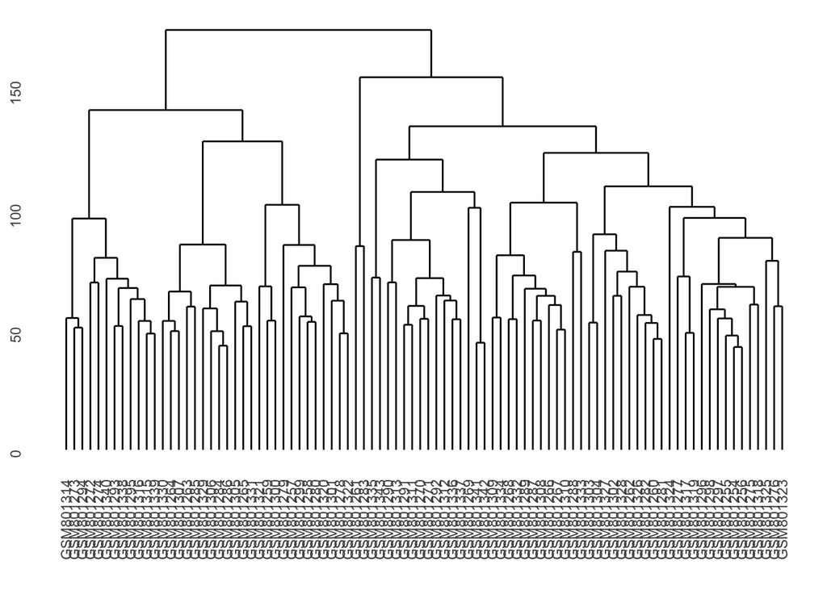

```r
#Loading packages
#install.packages("ggdendro") #Already loaded it so commenting it out
library("ggdendro")

# Calculate distance matrix and hierarchical clustering
distance.data <- dist(t(expression.data), method = "euclidean")
clustering <- hclust(distance.data, method = "average")

dendro <- ggdendrogram(clustering, rotate = FALSE, size = 1)
print(dendro)
```

# 3.1 Color Dendrogram by Genotype

*What I’m doing:* Coloring sample labels on the dendrogram by genotype to explore grouping.

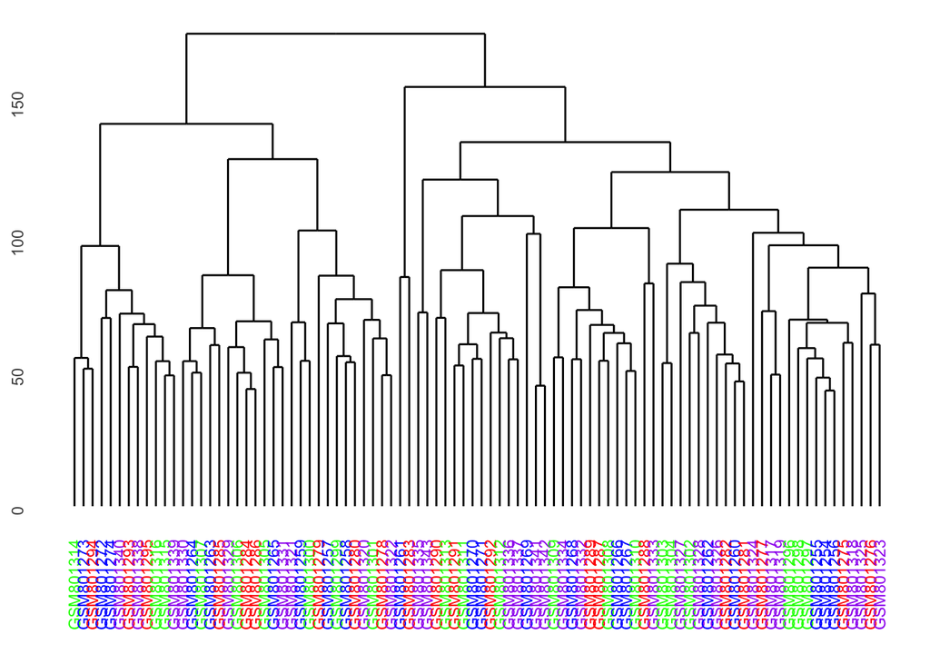

```r
# Order metadata to match dendrogram
extract.order <- clustering$order
order.imp.metadata <- imp.metadata.columns[extract.order, ]

# Define color mapping for genotypes
color.vector <- c("blue", "red", "green", "purple")
then.color <- character(nrow(order.imp.metadata))
for (i in seq_len(nrow(order.imp.metadata))) {
  geno <- order.imp.metadata[i, "genotype:ch1"]
  then.color[i] <- switch(
    geno,
    "Monsanto Z. mays line 1" = color.vector[1],
    "Monsanto Z. mays line 2" = color.vector[2],
    "Monsanto Z. mays line 3" = color.vector[3],
    "Monsanto Z. mays line 4" = color.vector[4],
    "black"
  )
}
dendro + theme(axis.text.x = element_text(color = then.color))
```

# 3.2 Color Dendrogram by Growth Nutrient

*What I’m doing:* Coloring sample labels by growth nutrient condition.

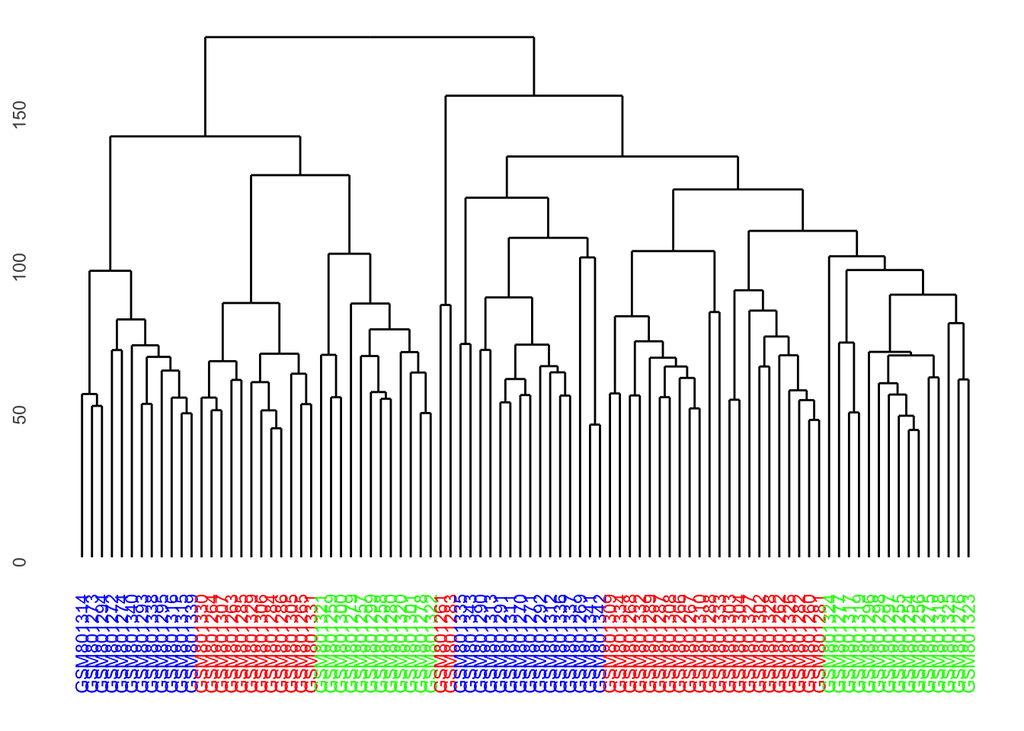

```r
# Define color mapping for nutrient treatments
color.vector.growth <- c("blue", "red", "green")
then.color.growth <- character(nrow(order.imp.metadata))
for (i in seq_len(nrow(order.imp.metadata))) {
  nut <- order.imp.metadata[i, "growth nutrient:ch1"]
  then.color.growth[i] <- switch(
    nut,
    "20mM NH4NO3" = color.vector.growth[1],
    "2mM and then 20mM NH4NO3" = color.vector.growth[2],
    "2mM NH4NO3" = color.vector.growth[3],
    "black"
  )
}
dendro + theme(axis.text.x = element_text(color = then.color.growth))
```

# 3.3 Color Dendrogram by Sample Time

*What I’m doing:* Coloring sample labels by sampling time.

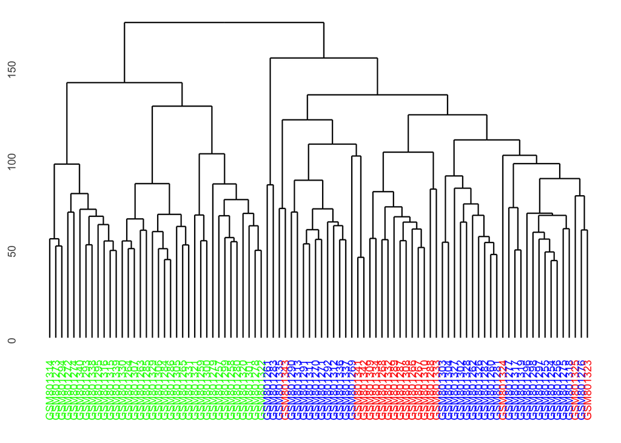

```r
# Define color mapping for sample times
color.vector.time <- c("blue", "red", "green")
then.color.time <- character(nrow(order.imp.metadata))
for (i in seq_len(nrow(order.imp.metadata))) {
  tm <- order.imp.metadata[i, "sampletime:ch1"]
  then.color.time[i] <- switch(
    tm,
    "10AM day1" = color.vector.time[1],
    "10AM day2" = color.vector.time[2],
    "11PM day1" = color.vector.time[3],
    "black"
  )
}
dendro + theme(axis.text.x = element_text(color = then.color.time))
```

# 4. Filter Low-Expression Genes

**Objective:** Retain genes with total expression above the median.

```r
# Filter Low-Expression Genes
# Convert to data frame with gene_id column
expr_df <- tibble::rownames_to_column(as.data.frame(expression.data), var = "gene_id")

# Compute sum of expression values across numeric columns only
numeric_cols <- sapply(expr_df, is.numeric)
expr_df$sum.expr <- rowSums(expr_df[, numeric_cols], na.rm = TRUE)

# Calculate median of summed expression
median.sum <- median(expr_df$sum.expr)

# Subset genes above the median
gfiltered <- expr_df[expr_df$sum.expr > median.sum, ]

# Remove the helper column
gfiltered$sum.expr <- NULL

# Restore row names from gene_id and drop that column
rownames(gfiltered) <- gfiltered$gene_id
filtered.genes <- gfiltered[, setdiff(names(gfiltered), "gene_id")]
```

# 5. Three-Way ANOVA for Gene Prioritization

**Objective:** Identify genes significantly affected by genotype, nutrient, or time.

```r
# ~~~~~~~~~~~~~~~~~~~~~~~~~~~~~~~~~~~~~~~~~~~~~~~~~~~~~~~~~~~~~~ #
# The following function will return the smallest p-value associated with a non-intercept model term
# This is different from the model F-statistic which does incorporate the intercept term
# There are better ways to do this; use this way because it's relatively fast and kinda ok
# Arguments:
#   1) a vector of expression values
#   2) a dataframe with the three factors as three columns
msk3wayAnova <- function(expvalue, expfactors) {
  templm<- lm(as.numeric(expvalue) ~ as.factor(expfactors[,1]) +
              as.factor(expfactors[,2]) +
              as.factor(expfactors[,3]))
  return(min(summary(templm)$coef[-1,4]))
}
# ~~~~~~~~~~~~~~~~~~~~~~~~~~~~~~~~~~~~~~~~~~~~~~~~~~~~~~~~~~~~~~ #

# Apply the above function to each row of the expression values.
imp.metadata.columns.nolabels <- imp.metadata.columns[,2:4]
# filtered.genes already has the gene_id column removed (Section 4),
# so it holds exactly the 90 sample columns, in the same order as the metadata rows
filtered.gene.expression.norowsums <- filtered.genes
stopifnot(ncol(filtered.gene.expression.norowsums) == nrow(imp.metadata.columns.nolabels))


anovaPvalues <- apply(filtered.gene.expression.norowsums, imp.metadata.columns.nolabels, MARGIN = 1, FUN = msk3wayAnova)

str(anovaPvalues)
```

```
##  Named num [1:42123] 7.18e-14 3.86e-15 3.82e-03 1.74e-05 2.51e-12 ...
##  - attr(*, "names")= chr [1:42123] "A1ZM000001_a_at" "A1ZM000001_s_at" "A1ZM000002_a_at" "A1ZM000005_a_at" ...
```

```r
max(anovaPvalues)
```

```
## [1] 0.6868352
```

```r
min(anovaPvalues)
```

```
## [1] 6.632008e-90
```

# 6. Select Top 1000 Genes

**Objective:** Choose genes with the smallest ANOVA p-values.

```r
#Identifying genes with the lowest p-values
#Creating a data frame with the p value

#For some reason I lost my gene names - so adding that again
pval.df <- tibble::rownames_to_column(as.data.frame(anovaPvalues), var = "gene")

top1000 <- pval.df %>%
  arrange(anovaPvalues) %>%
  slice(1:1000) %>%
  pull(gene)

selected.data <- filtered.genes[top1000, ]

# 1000 genes x 90 samples, gene IDs kept as row names
lowest.p.value.final <- selected.data
dim(lowest.p.value.final)
```

```
## [1] 1000   90
```

# 7. Heatmap of Top Genes

**Objective:** Visualize z-scored expression for top genes.

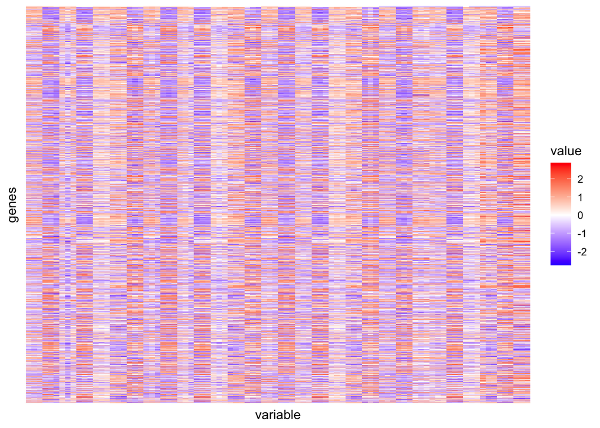

```r
#From class notes getting the z scores
centered.data <- sweep(lowest.p.value.final, 1, rowMeans(lowest.p.value.final), FUN = "-")
centered.data.std.dev <-apply(centered.data , 1, sd)

recentered.data <- sweep(centered.data, 1, centered.data.std.dev, FUN = "/" )

# Keep a numeric-only copy of the z-scores for distance calculations later
z.scores <- recentered.data

recentered.data$genes <- rownames(recentered.data)
recentered.data.melt<- melt(recentered.data)

library(MASS)
library(reshape2)
#Online - https://www.r-graph-gallery.com/79-levelplot-with-ggplot2.html
  ggplot(recentered.data.melt, aes(x  = variable, y= genes, fill=  value)) +
    geom_tile() +
    scale_fill_gradient2(
                        low = "blue", na.value = "white",
                        high = "red") + theme(axis.text.x = element_blank(), axis.ticks.x =  element_blank()) + theme(axis.text.y =  element_blank(),  axis.ticks.y =  element_blank())
```

# 8. Gene Clustering Heatmap

**Objective:** Cluster genes and reorder heatmap rows accordingly.

```r
#Samething as before
#first calculating distance  #Copied code from above

distance.data.new <- dist(z.scores, method ="euclidean")

clustering.new <- hclust(distance.data.new , method = "average")
clustering.new
```

```
##
## Call:
## hclust(d = distance.data.new, method = "average")
##
## Cluster method   : average
## Distance         : euclidean
## Number of objects: 1000
```

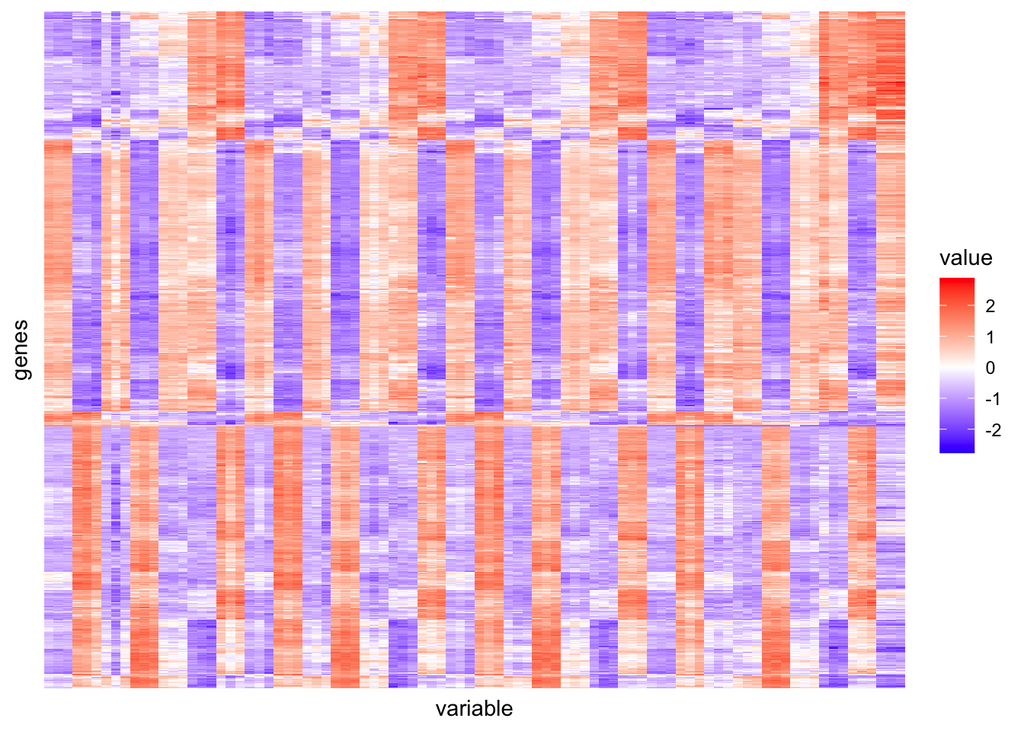

```r
#One of the things in the list is the order - extract the order - make vector

extract.order.new <- clustering.new$order

ordered.names.data <- rownames(recentered.data)[extract.order.new]

ggplot(recentered.data.melt, aes(x  = variable, y= genes, fill=  value)) +
    geom_tile() +
    scale_fill_gradient2(
                        low = "blue", na.value = "white",
                        high = "red") + theme(axis.text.x = element_blank(), axis.ticks.x =  element_blank()) + theme(axis.text.y =  element_blank(),  axis.ticks.y =  element_blank()) + scale_y_discrete(limits= ordered.names.data)
```

# 8.1 Reorder the biological *samples* in the heatmap based on the *genotypes*. Print the new heatmap.

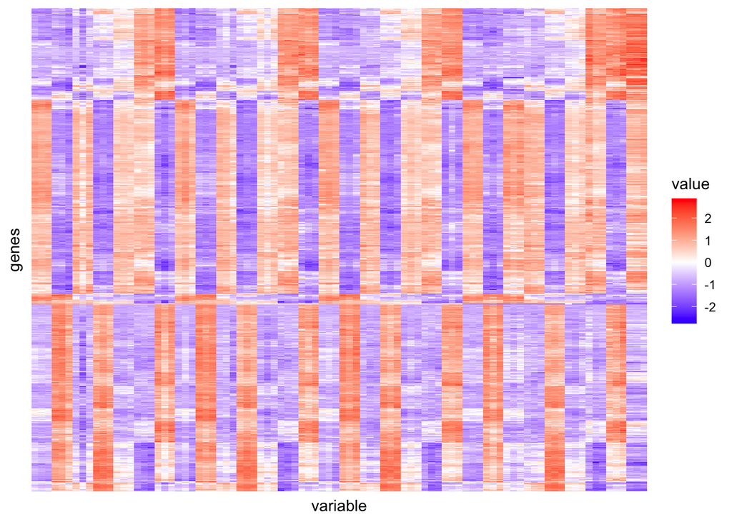

```r
arrange.genotypes <-imp.metadata.columns %>% arrange(`genotype:ch1`)
arrange.genotypes.geo <- arrange.genotypes[,1]


ggplot(recentered.data.melt, aes(x  = variable, y= genes, fill=  value)) +
    geom_tile() +
    scale_fill_gradient2(
                        low = "blue", na.value = "white",
                        high = "red") + theme(axis.text.x = element_blank(), axis.ticks.x =  element_blank()) + theme(axis.text.y =  element_blank(),  axis.ticks.y =  element_blank()) + scale_y_discrete(limits= ordered.names.data) + scale_x_discrete(limits= arrange.genotypes.geo  )
```

# 8.2 Reorder the biological *samples* in the heatmap based on the *growth nutrients*. Print the new heatmap.

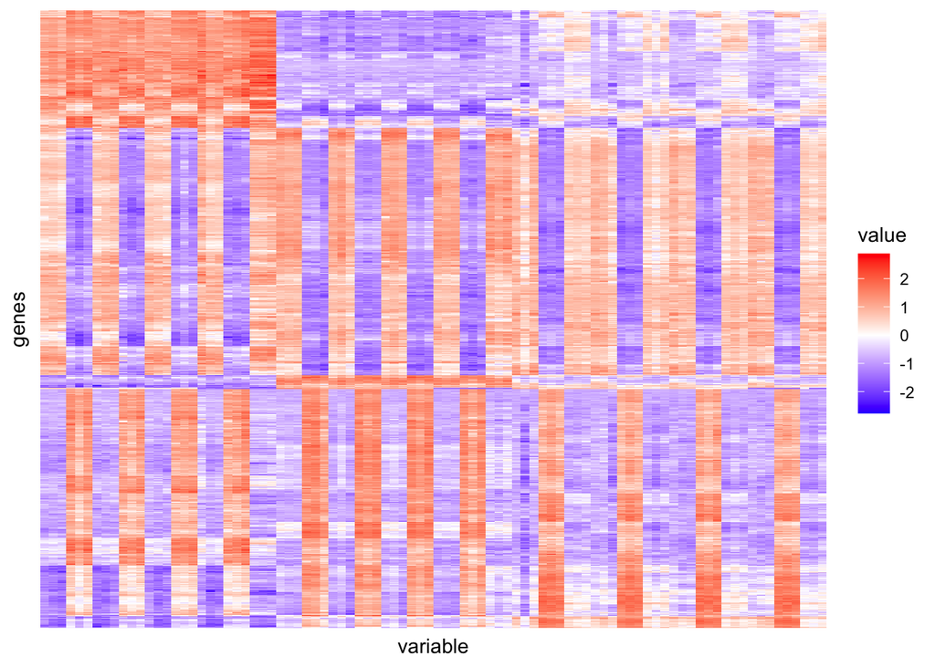

```r
arrange.growth <-imp.metadata.columns %>% arrange(`growth nutrient:ch1`)
arrange.genotypes.growth <- arrange.growth[,1]


ggplot(recentered.data.melt, aes(x  = variable, y= genes, fill=  value)) +
    geom_tile() +
    scale_fill_gradient2(
                        low = "blue", na.value = "white",
                        high = "red") + theme(axis.text.x = element_blank(), axis.ticks.x =  element_blank()) + theme(axis.text.y =  element_blank(),  axis.ticks.y =  element_blank()) + scale_y_discrete(limits= ordered.names.data) + scale_x_discrete(limits= arrange.genotypes.growth)
```

# 8.3 Reorder the biological *samples* in the heatmap based on the *sample time*. Print the new heatmap.

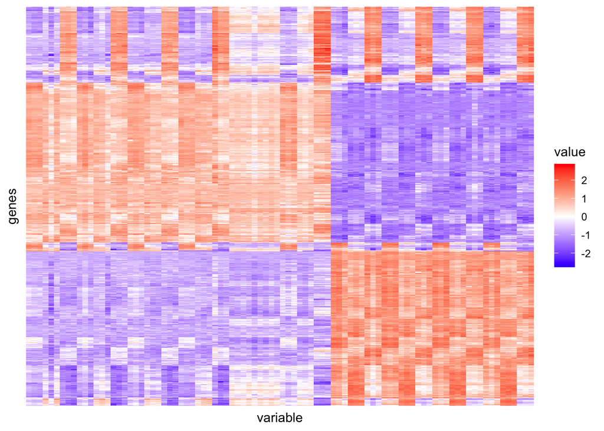

```r
arrange.time <-imp.metadata.columns %>% arrange(`sampletime:ch1`)
arrange.genotypes.time <- arrange.time[,1]


ggplot(recentered.data.melt, aes(x  = variable, y= genes, fill=  value)) +
    geom_tile() +
    scale_fill_gradient2(
                        low = "blue", na.value = "white",
                        high = "red") + theme(axis.text.x = element_blank(), axis.ticks.x =  element_blank()) + theme(axis.text.y =  element_blank(),  axis.ticks.y =  element_blank()) + scale_y_discrete(limits= ordered.names.data) + scale_x_discrete(limits= arrange.genotypes.time)
```

# 8.4 Interpreting patterns using the heatmaps

Based on the heat map - we plotted genes on the Y axis and GSM on the X axis, so if we look along the X-axis we can see how for the one gene how the expression is changing. Therefore, we can say that gene is varying alot if we see more patterning along the X-axis. On the basis of this, when we group by genotypes, we see alot of change (more patterning), showing that genotypes don’t have a profound effect on the change in the gene expression. This correlates with the dendogram that we saw - where when we order by genotypes, we dont see a really see groupings for similar genotypes. When we look at the heatmap for time - we see that when we group by time, we see patterns that are constant - or large clusters, indicating time does affect gene expression. Therefore sample time based on heatmaps has the most effect on gene expression.

# 8.5 Creating discrete cluster

Using the heatmaps in the previous section, we see - two clusters that change according to sample time, and one cluster that changes according to nutrient.

```r
#3 clusters - based on the above

cut.the.tree <- data.frame(group = cutree(clustering.new, k = 3)) #Storing it as a data drame - because otherwise it returns a vector
```

```r
#Creating a heatmap with only the genes in the largest group. Order the x-axis by `sampletime`.
#Determine how many genes have 1 or 2 or 3
table(cut.the.tree$group)
```

```
##
##   1   2   3
## 409 191 400
```

```r
# Pick the largest group from the counts rather than hard-coding it
largest.group <- as.integer(names(which.max(table(cut.the.tree$group))))
largest.group
```

```
## [1] 1
```

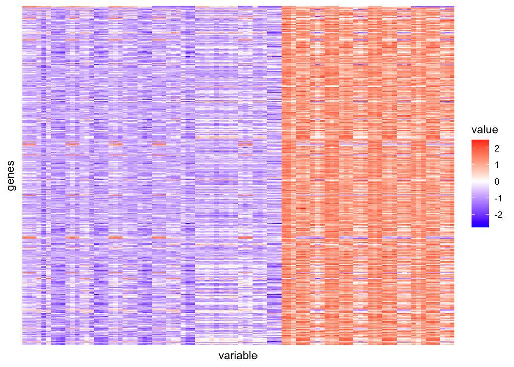

```r
cut.the.tree<- rownames_to_column(cut.the.tree)

#get names of genes in the largest group

largest.group.gene <- cut.the.tree[cut.the.tree$group == largest.group, 1] %>% unlist()

#TRYING - DOES NOT WORK
# cut.1 <- cut.the.tree[cut.the.tree$group == 1,]
# genes.cut.1<- cut.1[,1]
# genes.cut.1.new <- as.data.frame(genes.cut.1) #converting to data frame

largest.group.gene.data<- recentered.data[largest.group.gene,]
# largest.genes.gene <- as.data.frame(largest.group.gene.1)
largest.group.gene.data.melt <- melt(largest.group.gene.data)

#TRYING! DOESNT WORK _ DO NOT USE
#largest.group.gene <- melt(largest.group.gene) #I have two columns of the same thing - I will remove it to confuse
#largest.group.gene<- largest.group.gene[,-3]


#So now doing the time thing like before
# arrange.time.new <-imp.metadata.columns %>% filter()
# arrange.genotypes.time <- arrange.time[,1]
# extract.order.new <- clustering.new$order
# ordered.names.data <- rownames(recentered.data)[extract.order.new]

#GG plot code
ggplot(largest.group.gene.data.melt, aes(x  = variable, y= genes, fill=  value)) +
    geom_tile() +
    scale_fill_gradient2(
                        low = "blue", na.value = "white",
                        high = "red") + theme(axis.text.x = element_blank(), axis.ticks.x =  element_blank()) + theme(axis.text.y =  element_blank(),  axis.ticks.y =  element_blank())+scale_x_discrete(limits= arrange.genotypes.time)
```

# 9 Silhouette Analysis for Gene Clusters

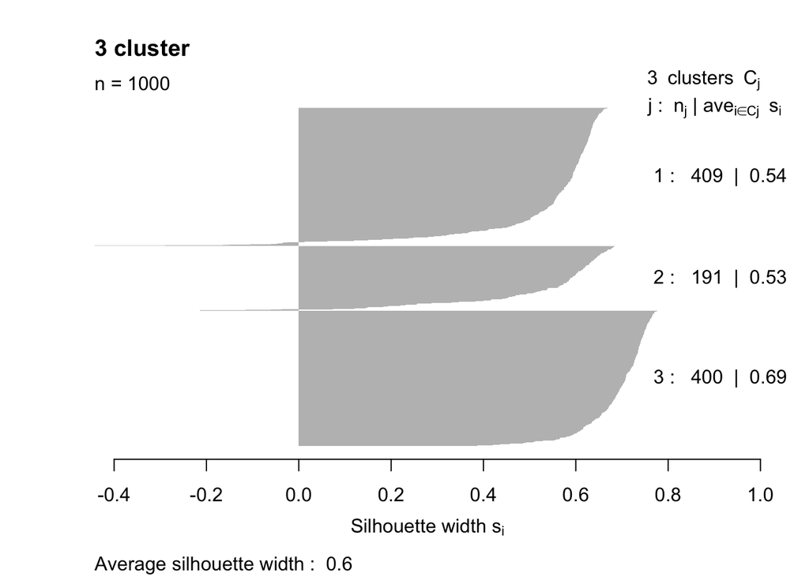

```r
library(cluster)

empty.data.frame <-data.frame(ncol = 3)
k.values.new <- c(3,4,5)
for (i in 1:length(k.values.new))  {
  empty.data.frame.new <- cutree(clustering.new, k = k.values.new[i])
  empty.data.frame <-  cbind(empty.data.frame, empty.data.frame.new)
 }

#These columns generated have bad names - renaming it
three.cluster.names <- c("ncol","3 cluster", "4 cluster", "5 cluster")
colnames(empty.data.frame) <- three.cluster.names

#Calculate silhoutte
three.cluster <- silhouette(empty.data.frame[,2],  distance.data.new)
four.cluster <- silhouette(empty.data.frame[,3],  distance.data.new)
five.cluster <- silhouette(empty.data.frame[,4],  distance.data.new)

#Make a plot now

plot.three.cluster <- plot(three.cluster, border = NA,main = "3 cluster")
```

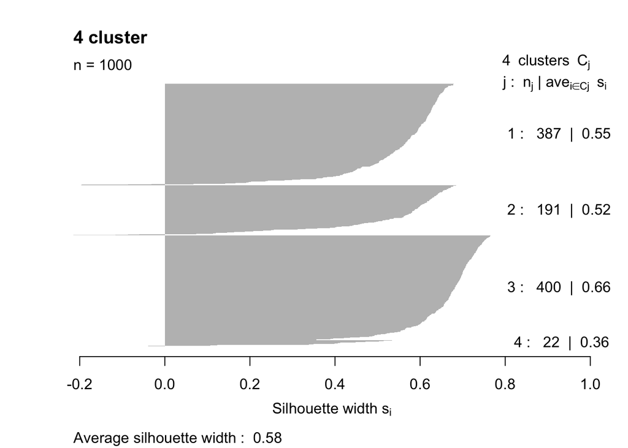

```r
plot.four.cluster <- plot(four.cluster, border = NA, main = "4 cluster")
```

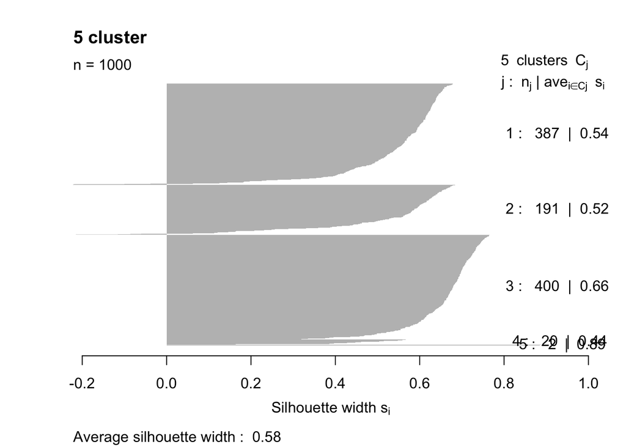

```r
plot.five.cluster <- plot(five.cluster, border = NA, main = "5 cluster")
```

Comparing the results to your original guess for the optimal number of groups. The number of optimal of clusters should be 3. This correlates with what we set before. We can infer this with the average silhoutte width - which is the maximum for 3 clusters.

# 10. Principal Component Analysis

**Objective:** Perform PCA on the top genes and plot PC1 vs PC2.

```r
#Using my code from HW11
straight.line.pca <- prcomp(t(lowest.p.value.final), center=T, scale=T)
summary(straight.line.pca)
```

```
## Importance of components:
##                            PC1     PC2     PC3     PC4     PC5     PC6     PC7     PC8     PC9    PC10    PC11    PC12    PC13    PC14    PC15    PC16    PC17
## Standard deviation     26.0971 14.2080 7.32957 3.97171 2.88276 2.43960 2.32713 2.00574 1.68171 1.40072 1.23043 1.14296 1.07937 0.98665 0.92410 0.86231 0.82486
## Proportion of Variance  0.6811  0.2019 0.05372 0.01577 0.00831 0.00595 0.00542 0.00402 0.00283 0.00196 0.00151 0.00131 0.00117 0.00097 0.00085 0.00074 0.00068
## Cumulative Proportion   0.6811  0.8829 0.93665 0.95242 0.96073 0.96669 0.97210 0.97612 0.97895 0.98091 0.98243 0.98373 0.98490 0.98587 0.98673 0.98747 0.98815
##                          PC18    PC19    PC20    PC21   PC22    PC23    PC24    PC25    PC26    PC27   PC28    PC29    PC30    PC31    PC32    PC33    PC34
## Standard deviation     0.7739 0.73458 0.67296 0.64885 0.6361 0.61896 0.60340 0.58904 0.57202 0.55276 0.5514 0.53935 0.52322 0.49976 0.48842 0.47942 0.47591
## Proportion of Variance 0.0006 0.00054 0.00045 0.00042 0.0004 0.00038 0.00036 0.00035 0.00033 0.00031 0.0003 0.00029 0.00027 0.00025 0.00024 0.00023 0.00023
## Cumulative Proportion  0.9888 0.98929 0.98974 0.99016 0.9906 0.99095 0.99132 0.99166 0.99199 0.99230 0.9926 0.99289 0.99316 0.99341 0.99365 0.99388 0.99411
##                           PC35    PC36    PC37   PC38    PC39    PC40    PC41    PC42    PC43    PC44    PC45    PC46    PC47    PC48    PC49    PC50    PC51
## Standard deviation     0.46924 0.46410 0.45452 0.4433 0.43416 0.43113 0.42564 0.41949 0.40996 0.39786 0.39454 0.38880 0.38437 0.37885 0.37107 0.36542 0.35784
## Proportion of Variance 0.00022 0.00022 0.00021 0.0002 0.00019 0.00019 0.00018 0.00018 0.00017 0.00016 0.00016 0.00015 0.00015 0.00014 0.00014 0.00013 0.00013
## Cumulative Proportion  0.99433 0.99454 0.99475 0.9950 0.99514 0.99532 0.99550 0.99568 0.99585 0.99600 0.99616 0.99631 0.99646 0.99660 0.99674 0.99687 0.99700
##                           PC52    PC53    PC54    PC55    PC56    PC57    PC58   PC59   PC60   PC61    PC62    PC63    PC64    PC65    PC66    PC67    PC68
## Standard deviation     0.35382 0.35060 0.34734 0.34217 0.33736 0.32940 0.32428 0.3198 0.3162 0.3124 0.30653 0.30426 0.30096 0.29868 0.29446 0.28954 0.28484
## Proportion of Variance 0.00013 0.00012 0.00012 0.00012 0.00011 0.00011 0.00011 0.0001 0.0001 0.0001 0.00009 0.00009 0.00009 0.00009 0.00009 0.00008 0.00008
## Cumulative Proportion  0.99713 0.99725 0.99737 0.99749 0.99760 0.99771 0.99782 0.9979 0.9980 0.9981 0.99821 0.99830 0.99839 0.99848 0.99857 0.99865 0.99873
##                           PC69    PC70    PC71    PC72    PC73    PC74    PC75    PC76    PC77    PC78    PC79    PC80    PC81    PC82    PC83    PC84    PC85
## Standard deviation     0.28258 0.27734 0.27283 0.26917 0.26698 0.26390 0.25569 0.25558 0.25141 0.24661 0.24493 0.24015 0.23886 0.23463 0.23166 0.22919 0.22104
## Proportion of Variance 0.00008 0.00008 0.00007 0.00007 0.00007 0.00007 0.00007 0.00007 0.00006 0.00006 0.00006 0.00006 0.00006 0.00006 0.00005 0.00005 0.00005
## Cumulative Proportion  0.99881 0.99889 0.99896 0.99904 0.99911 0.99918 0.99924 0.99931 0.99937 0.99943 0.99949 0.99955 0.99961 0.99966 0.99972 0.99977 0.99982
##                           PC86    PC87    PC88    PC89      PC90
## Standard deviation     0.22047 0.21978 0.20982 0.20346 1.503e-14
## Proportion of Variance 0.00005 0.00005 0.00004 0.00004 0.000e+00
## Cumulative Proportion  0.99987 0.99991 0.99996 1.00000 1.000e+00
```

# 10.1 Ploting PC1 and PC2

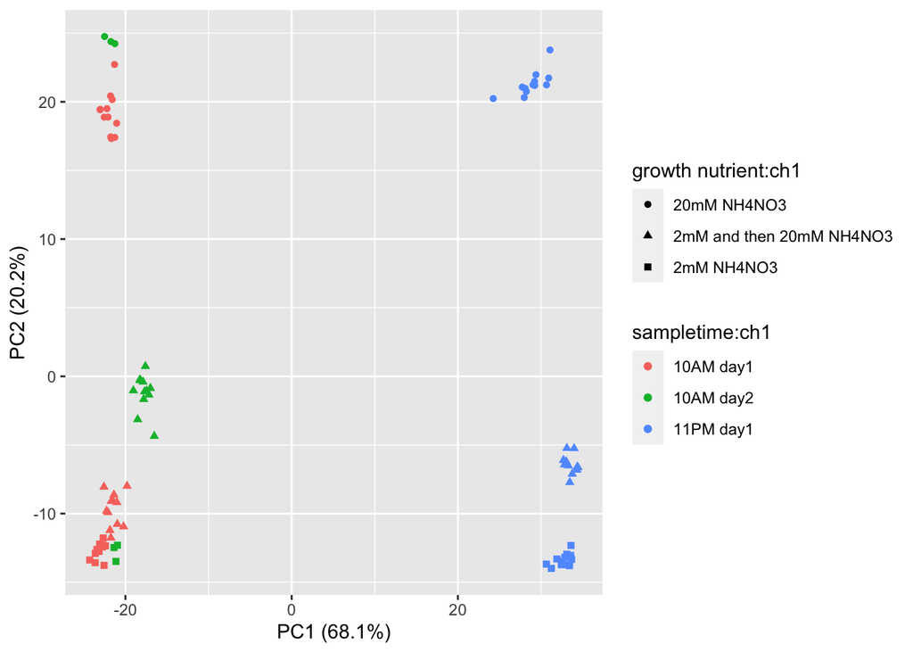

```r
growth.time.experiment.data <- imp.metadata.columns[, 3:4]

straight.line.pca.time.exp <- as.data.frame(cbind(as.data.frame(straight.line.pca$x), growth.time.experiment.data))

ggplot(straight.line.pca.time.exp, aes(x=PC1, y=PC2, shape=`growth nutrient:ch1` , col=`sampletime:ch1`)) +
  geom_point() +
  scale_fill_brewer() +
  labs(x = sprintf("PC1 (%.1f%%)", 100 * summary(straight.line.pca)$importance[2, 1]),
       y = sprintf("PC2 (%.1f%%)", 100 * summary(straight.line.pca)$importance[2, 2]))
```

# 10.2 Interpretion the data using the PCA plot

These results correlate with earlier analysis and we see that sampling time has the most effect on the variability in gene expression, followed by nutrients and then genotype. For the dendogram we could see for sampling time, the groupings showed a pattern, and the same was explained by the heat map, where for the time when we grouped it together, we could see pattern (and constantly changing patterns).